# Exploratory Analysis of Mesa County Public Health

Kurtis Bulock

10/2/2020

# Observations

- Representation of Race in the Survey vs County
- Lonlieness vs Social Discourse
  - All ages
  - Children
- Income vs. Danger
- Income vs Social Discourse

# Racial Representation

| Race | Survey Representation | County Represnetation |
| --- | --- | --- |
| Asian | 0.742 | 1.036 |
| Black/African American | 1.372 | 0.948 |
| Native American/Alaska Native | 5.193 | 1.534 |
| Native Hawaiian/Other Pacific Islander | 0.297 | 0.137 |
| White | 92.396 | 93.937 |

- Native American/Alaskin Native appear over represented in these survey results

County population data from https://www.census.gov/data/tables/time-series/demo/popest/2010s-counties-detail.html]

# Lonelieness and Social Discourse

- Loneliness is reported by Supplemental Need Family & Community Support Answer
- Lonileness is measured on a scale of 0-4
  - [0] NEVER
  - [1] RARELY
  - [2] SOMETIMES
  - [3] FAIRLY OFTEN
  - [4] ALWAYS
- Social Discourse is measured out of a total of 16 by adding all of the Core Need Safety answers 1-4
  - CN_SF_1-4 are measured by the following
    - [0] NEVER
    - [1] RARELY
    - [2] SOMETIMES
    - [3] FAIRLY OFTEN
    - [4] FREQUENTLY

# Loneliness in all Ages

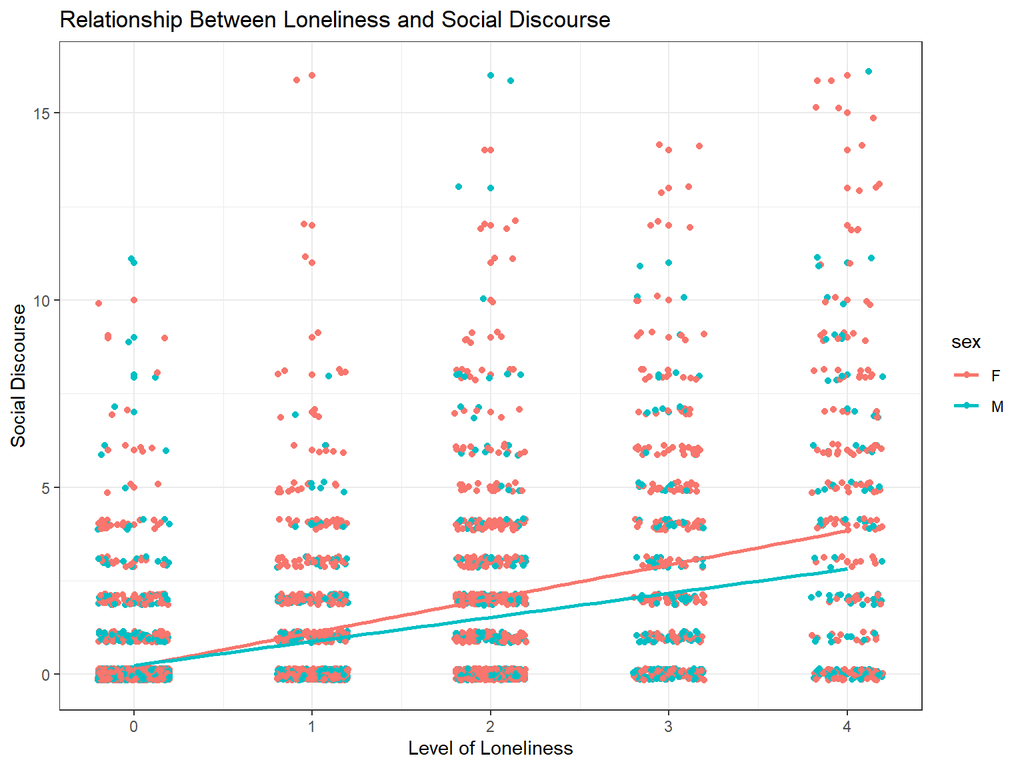

# Loneliness in Children (<18)

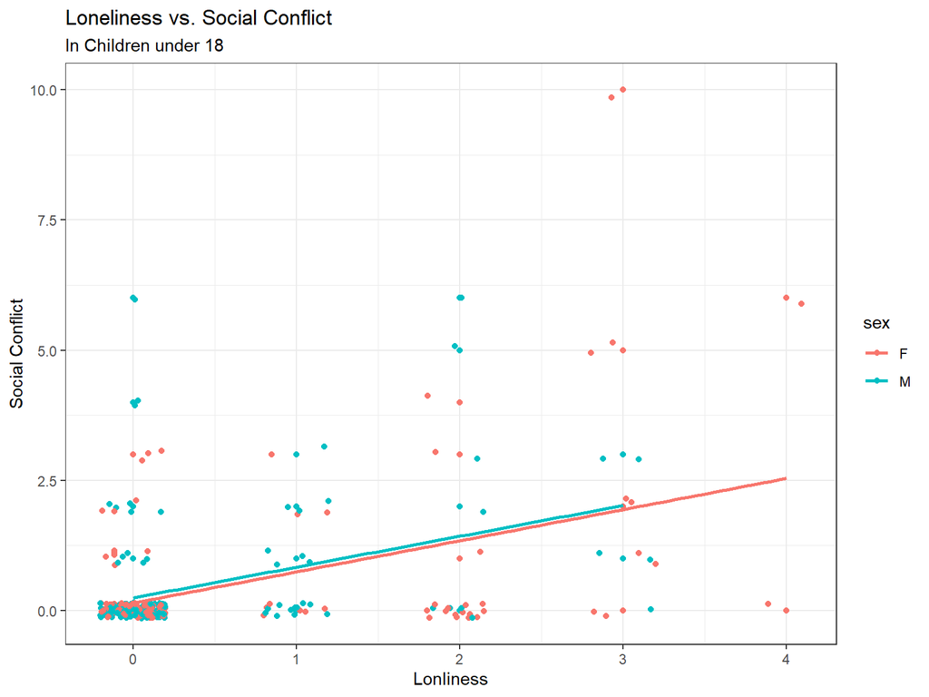

- This trend appears to be similar
- smaller data pool

# Future Work

- Loneliness may be important
- Can this be predicted accurately?

# How Does Wealth Relate to Household Dangers?

- Wealth is reported by Tell me About Yourself answer 6
  - LESS_THN_10K;
  - MORE_THN_10_LESS_THEN_15K
  - MORE_THN_15_LESS_THEN_20K
  - MORE_THN_20_LESS_THEN_25K
  - MORE_THN_25_LESS_THEN_35K
  - MORE_THN_35_LESS_THEN_50K
  - MORE_THN_50_LESS_THEN_75K
  - MORE_THN_75K
- Household Danger is measured out of a total of 7 by adding all of the Core Need Living Situation Answer 2
- Do you have problems with? [1] Yes, [2] No
  - Bug Infestation
  - Mold
  - Lead Paint
  - Inadequit Heat
  - Oven not Working
  - Smoke Detector not Working
  - Water Leaks

# Household Wealth and Danger

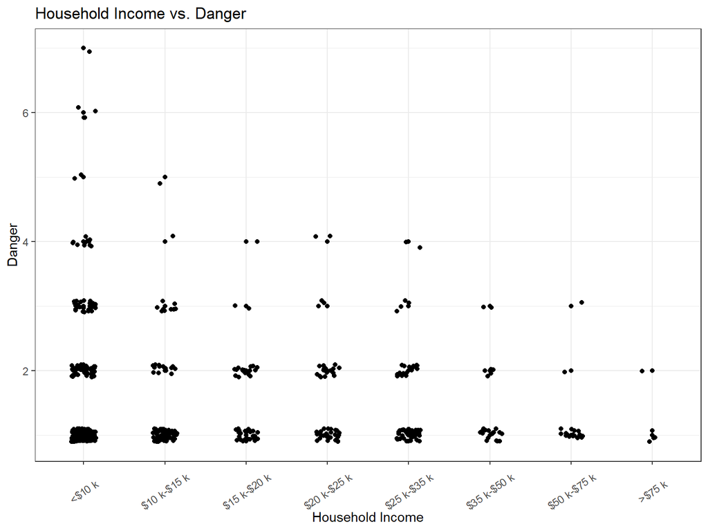